# Loading and preprocessing the data

## Loading and preprocessing the data

- Load the data

```r
activity_data <- read.csv("activity.csv")
```

## What is mean total number of steps taken per day?

```r
steps <- as.numeric(as.vector(activity_data$steps))
sum(steps, na.rm=TRUE)
```

```
## [1] 570608
```

- Make a histogram of the total number of steps taken each day

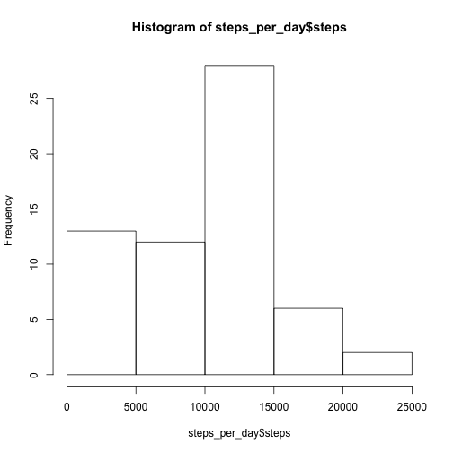

```r
steps_per_day <- aggregate(activity_data[1], by=activity_data[2], FUN=sum, na.rm=TRUE)
hist(steps_per_day$steps)
```

- Calculate and report the mean and median of the total number of steps taken per day

```r
mean(steps_per_day$steps, na.rm=TRUE)
```

```
## [1] 9354.23
```

```r
median(steps_per_day$steps, na.rm=TRUE)
```

```
## [1] 10395
```

## What is the average daily activity pattern?

- Make a time series plot (i.e. type = “l”) of the 5-minute interval (x-axis) and the average number of steps taken, averaged across all days (y-axis)

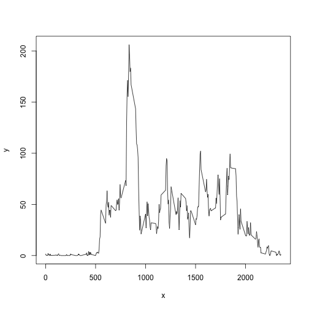

```r
activity_interval <- aggregate(activity_data$steps,by=activity_data[3],FUN=mean,na.rm=TRUE)
x = activity_interval$interval
y = activity_interval$x
plot(x,y, type="l")
```

- Which 5-minute interval, on average across all the days in the dataset, contains the maximum number of steps?

```r
maxsteps <- max(activity_interval$x)
activity_interval[ which(activity_interval$x == maxsteps), ]
```

```
##     interval        x
## 104      835 206.1698
```

The 835-minute intereval contains the max average number of steps (206).

## Imputing missing values

- Calculate and report the total number of missing values in the dataset

```r
sum(!complete.cases(activity_data))
```

```
## [1] 2304
```

Devise a strategy for filling in all of the missing values in the dataset.

```r
fill_values <- function(x) replace(x, is.na(x), mean(x, na.rm=TRUE))
```

Create a new dataset that is equal to the original dataset but with the missing data filled in.

```r
filled_data <- ddply(activity_data, ~interval, transform, steps=fill_values(steps))
```

Make a histogram of the total number of steps taken each day and Calculate and report the mean and median total number of steps taken per day.

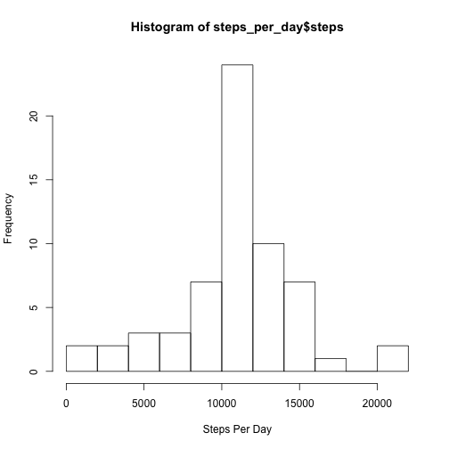

```r
steps_per_day <- aggregate(filled_data[1], by=filled_data[2], FUN=sum, na.rm=TRUE)
hist(steps_per_day$steps, breaks=10, xlab="Steps Per Day")
```

```r
mean(steps_per_day$steps)
```

```
## [1] 10766.19
```

```r
median(steps_per_day$steps)
```

```
## [1] 10766.19
```

## Are there differences in activity patterns between weekdays and weekends?

Create a new factor variable in the dataset with two levels – “weekday” and “weekend” indicating whether a given date is a weekday or weekend day.

```r
library(lubridate)
library(timeDate)
filled_data$date<- ymd(filled_data$date)
filled_data$weekday = ifelse(isWeekday(filled_data$date) == TRUE, "weekday", "weekend")
```

Make a panel plot containing a time series plot (i.e. type = “l”) of the 5-minute interval (x-axis) and the average number of steps taken, averaged across all weekday days or weekend days (y-axis)

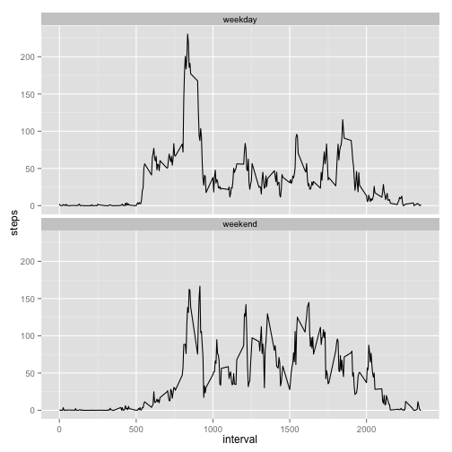

```r
library(ggplot2)
weekday_weekend <- aggregate(filled_data[1], by=filled_data[c(3,4)], FUN=mean)
plot <- ggplot(weekday_weekend, aes(x=interval, y=steps))
plot + geom_line() + facet_wrap(~weekday,nrow=2)
```